# lab7+8

```python
import pickle
import numpy as np
import matplotlib
import matplotlib.pyplot as plt
import scipy
from scipy import stats
import pandas as pd


plt.rcParams["figure.figsize"] = (10,8)
```

```python
# open the file of interest, and use pickle loading
infile = open ("higgs.pkl",'rb')
higgs = pickle.load(infile)


infile = open ("qcd.pkl",'rb')

qcd = pickle.load(infile)

# list all keys of the files
higgs.keys()
```

```
Index(['pt', 'eta', 'phi', 'mass', 'ee2', 'ee3', 'd2', 'angularity', 't1',
       't2', 't3', 't21', 't32', 'KtDeltaR'],
      dtype='object')
```

##### 1.Make a stacked histogram plot for the feature variable: mass.Evaluate expected significance without any event selection.Use Poisson statistics for significance calculation. Compare your number of 𝑁𝐻𝑖𝑔𝑔𝑠/(√𝑁𝑄𝐶𝐷). If they are equivalent, explain your findings.

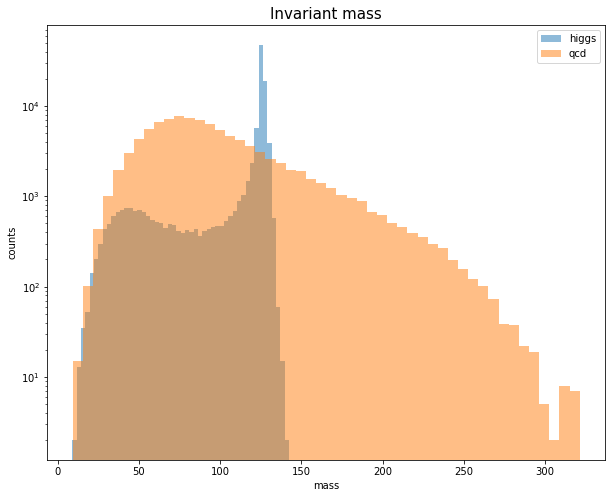

```python
plt.hist(higgs['mass'],bins=50, alpha=0.5,label='higgs',stacked=True)
plt.hist(qcd['mass'],bins=50,alpha=0.5,label='qcd', stacked=True)
plt.legend()
plt.xlabel("mass", size=10)
plt.yscale('log')
plt.ylabel("counts",size=10)
plt.title("Invariant mass",size=15);
```

The expected yields of Nqcd= 20000, and the expected yields of Nhiggs= 100.

```python
sigp= scipy.stats.norm.isf(stats.poisson.sf(20100, mu=20000))
print("The significance of observing Higgs (significance of measuring Nqcd+Nhiggs) is {:.2f}.".format(sigp))
```

```
The significance of observing Higgs (significance of measuring Nqcd+Nhiggs) is 0.71.
```

```python
sigc=100/(np.sqrt(20000))
print("𝑁𝐻𝑖𝑔𝑔𝑠/(√𝑁𝑄𝐶𝐷) = {:.2f}".format(sigc))
```

```
𝑁𝐻𝑖𝑔𝑔𝑠/(√𝑁𝑄𝐶𝐷) = 0.71
```

##### 2.Identify mass cuts to optimize the expected significance.Try different mass cuts systematically.Evaluate expeced significance for each set of mass cuts.Identify the set of the mass cuts which give you the highest significance.

Try different upper boundaries.

```python
cuts= np.linspace(120,max(higgs['mass']),10)

for i in range(len(cuts)):
    counth=0
    countq=0
    for j in range(len(higgs['mass'])):
        if higgs['mass'][j] <= cuts[i]:
            counth+=1
        if qcd['mass'][j] <= cuts[i]:
            countq+=1
    print("mass cut: {:.2f}".format(cuts[i]))
    Ncounth=counth*100/100000
    Ncountq=countq*20000/100000
    sig=Ncounth/(np.sqrt(Ncountq))
    print("𝑁𝐻𝑖𝑔𝑔𝑠/(√𝑁𝑄𝐶𝐷): {:.2f}".format(sig))
    i+=1
```

```
mass cut: 120.00
𝑁𝐻𝑖𝑔𝑔𝑠/(√𝑁𝑄𝐶𝐷): 0.18
mass cut: 122.49
𝑁𝐻𝑖𝑔𝑔𝑠/(√𝑁𝑄𝐶𝐷): 0.20
mass cut: 124.99
𝑁𝐻𝑖𝑔𝑔𝑠/(√𝑁𝑄𝐶𝐷): 0.31
mass cut: 127.48
𝑁𝐻𝑖𝑔𝑔𝑠/(√𝑁𝑄𝐶𝐷): 0.69
mass cut: 129.97
𝑁𝐻𝑖𝑔𝑔𝑠/(√𝑁𝑄𝐶𝐷): 0.77
mass cut: 132.47
𝑁𝐻𝑖𝑔𝑔𝑠/(√𝑁𝑄𝐶𝐷): 0.78
mass cut: 134.96
𝑁𝐻𝑖𝑔𝑔𝑠/(√𝑁𝑄𝐶𝐷): 0.78
mass cut: 137.45
𝑁𝐻𝑖𝑔𝑔𝑠/(√𝑁𝑄𝐶𝐷): 0.77
mass cut: 139.95
𝑁𝐻𝑖𝑔𝑔𝑠/(√𝑁𝑄𝐶𝐷): 0.77
mass cut: 142.44
𝑁𝐻𝑖𝑔𝑔𝑠/(√𝑁𝑄𝐶𝐷): 0.77
```

Try different lower boundaries.

```python
cuts= np.linspace(95,130,10)
cutval=[]
sigval=[]
for i in range(len(cuts)):
    counth=0
    countq=0
    for j in range(len(higgs['mass'])):
        if higgs['mass'][j] >= cuts[i]:
            counth+=1
        if qcd['mass'][j]>= cuts[i]:
            countq+=1
    Ncounth=counth*100/100000
    Ncountq=countq*20000/100000
    sig=Ncounth/(np.sqrt(Ncountq))
    #cutval.append(cuts[i])
    #sigval.append(sig)
    print("mass cut: {:.2f}".format(cuts[i]))
    print("𝑁𝐻𝑖𝑔𝑔𝑠/(√𝑁𝑄𝐶𝐷): {:.2f}".format(sig))
    i+=1
```

```
mass cut: 95.00
𝑁𝐻𝑖𝑔𝑔𝑠/(√𝑁𝑄𝐶𝐷): 0.93
mass cut: 98.89
𝑁𝐻𝑖𝑔𝑔𝑠/(√𝑁𝑄𝐶𝐷): 0.96
mass cut: 102.78
𝑁𝐻𝑖𝑔𝑔𝑠/(√𝑁𝑄𝐶𝐷): 1.00
mass cut: 106.67
𝑁𝐻𝑖𝑔𝑔𝑠/(√𝑁𝑄𝐶𝐷): 1.03
mass cut: 110.56
𝑁𝐻𝑖𝑔𝑔𝑠/(√𝑁𝑄𝐶𝐷): 1.07
mass cut: 114.44
𝑁𝐻𝑖𝑔𝑔𝑠/(√𝑁𝑄𝐶𝐷): 1.10
mass cut: 118.33
𝑁𝐻𝑖𝑔𝑔𝑠/(√𝑁𝑄𝐶𝐷): 1.12
mass cut: 122.22
𝑁𝐻𝑖𝑔𝑔𝑠/(√𝑁𝑄𝐶𝐷): 1.11
mass cut: 126.11
𝑁𝐻𝑖𝑔𝑔𝑠/(√𝑁𝑄𝐶𝐷): 0.45
mass cut: 130.00
𝑁𝐻𝑖𝑔𝑔𝑠/(√𝑁𝑄𝐶𝐷): 0.04
```

After comparison, the mass cut [118.33,132.44] gives good significance.

```python
cuts=[118.33,132]

indexh=[]
indexq=[]

counth=0
countq=0
for j in range(len(higgs['mass'])):
    if higgs['mass'][j] >= cuts[0] and higgs['mass'][j]<= cuts[1] :
        indexh.append(j)
        counth+=1
    if qcd['mass'][j]>= cuts[0] and qcd['mass'][j]<= cuts[1] :
        indexq.append(j)
        countq+=1
Ncounth=counth*100/100000
Ncountq=countq*20000/100000
sig=Ncounth/(np.sqrt(Ncountq))
#cutval.append(cuts[i])
#sigval.append(sig)
print("mass cut: [118.33,142.44]")
print("Nhiggs= {:.0f}".format(Ncounth))
print("Nqcd= {:.0f}".format(Ncountq))
print("𝑁𝐻𝑖𝑔𝑔𝑠/(√𝑁𝑄𝐶𝐷): {:.2f}".format(sig))
```

[output not shown]

## 3.Make stacked histogram plots for the rest of features. Set A of plots without any event selection. Can you identify another feature as discriminative as mass feature (i.e. equal or better significance after feature cut). Set B of plots with your optimal mass cuts. Can you identify additional feature to further imrpove expected signifiance?

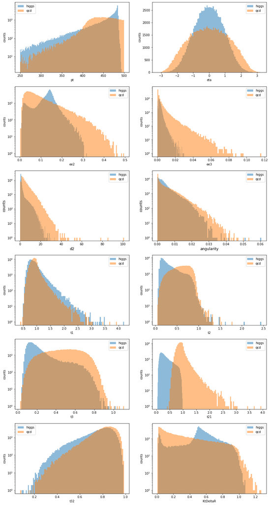

```python
fig, ax= plt.subplots(6,2,figsize=(15,30))

ax[0,0].hist(higgs['pt'],bins=200,alpha=0.5,label='higgs',stacked=True)
ax[0,0].hist(qcd['pt'],bins=200,alpha=0.5,label='qcd',stacked=True)
ax[0,0].legend()
ax[0,0].set_xlabel("pt", size=10)
ax[0,0].set_ylabel("counts",size=10)
#ax[0,0].title("Transverse Momentum(Set A)",size=15)
ax[0,0].set_yscale('log')

ax[0,1].hist(higgs['eta'],bins=100,alpha=0.5,label='higgs',stacked=True)
ax[0,1].hist(qcd['eta'],bins=100,alpha=0.5,label='qcd',stacked=True)
ax[0,1].legend()
ax[0,1].set_xlabel("eta", size=10)
ax[0,1].set_ylabel("counts",size=10)
#ax[0,1].title("eta (pseudorapidity) (Set A)",size=15);

ax[1,0].hist(higgs['ee2'],bins=100,alpha=0.5,label='higgs',stacked=True)
ax[1,0].hist(qcd['ee2'],bins=100,alpha=0.5,label='qcd',stacked=True)
ax[1,0].legend()
ax[1,0].set_xlabel("ee2", size=10)
ax[1,0].set_yscale('log')
ax[1,0].set_ylabel("counts",size=10)
#plt.title("ee2 (Set A)",size=15)

ax[1,1].hist(higgs['ee3'],bins=100,alpha=0.5,label='higgs',stacked=True)
ax[1,1].hist(qcd['ee3'],bins=100,alpha=0.5,label='qcd',stacked=True)
ax[1,1].legend()
ax[1,1].set_xlabel("ee3", size=10)
ax[1,1].set_yscale('log')
ax[1,1].set_ylabel("counts",size=10)
#plt.title("ee3 (Set A)",size=15);

ax[2,0].hist(higgs['d2'],bins=100,alpha=0.5,label='higgs',stacked=True)
ax[2,0].hist(qcd['d2'],bins=100,alpha=0.5,label='qcd',stacked=True)
ax[2,0].legend()
ax[2,0].set_xlabel("d2", size=12)
ax[2,0].set_yscale('log')
ax[2,0].set_ylabel("counts",size=12)
#ax[2,0].title("d2 (Set A)",size=15);

ax[2,1].hist(higgs['angularity'],bins=100,alpha=0.5,label='higgs',stacked=True)
ax[2,1].hist(qcd['angularity'],bins=100,alpha=0.5,label='qcd',stacked=True)
ax[2,1].legend()
ax[2,1].set_xlabel("angularity", size=12)
ax[2,1].set_yscale('log')
ax[2,1].set_ylabel("counts",size=12)
#ax[2,1].title("angularity (Set A)",size=15);


ax[3,0].hist(higgs['t1'],bins=100,alpha=0.5,label='higgs',stacked=True)
ax[3,0].hist(qcd['t1'],bins=100,alpha=0.5,label='qcd',stacked=True)
ax[3,0].legend()
ax[3,0].set_xlabel("t1", size=10)
ax[3,0].set_yscale('log')
ax[3,0].set_ylabel("counts",size=10)

ax[3,1].hist(higgs['t2'],bins=100,alpha=0.5,label='higgs',stacked=True)
ax[3,1].hist(qcd['t2'],bins=100,alpha=0.5,label='qcd',stacked=True)
ax[3,1].legend()
ax[3,1].set_xlabel("t2", size=10)
ax[3,1].set_yscale('log')
ax[3,1].set_ylabel("counts",size=10)

ax[4,0].hist(higgs['t3'],bins=100,alpha=0.5,label='higgs',stacked=True)
ax[4,0].hist(qcd['t3'],bins=100,alpha=0.5,label='qcd',stacked=True)
ax[4,0].legend()
ax[4,0].set_xlabel("t3", size=10)
ax[4,0].set_yscale('log')
ax[4,0].set_ylabel("counts",size=10)


ax[4,1].hist(higgs['t21'],bins=100,alpha=0.5,label='higgs',stacked=True)
ax[4,1].hist(qcd['t1'],bins=100,alpha=0.5,label='qcd',stacked=True)
ax[4,1].legend()
ax[4,1].set_xlabel("t21", size=10)
ax[4,1].set_yscale('log')
ax[4,1].set_ylabel("counts",size=10)


ax[5,0].hist(higgs['t32'],bins=100,alpha=0.5,label='higgs',stacked=True)
ax[5,0].hist(qcd['t32'],bins=100,alpha=0.5,label='qcd',stacked=True)
ax[5,0].legend()
ax[5,0].set_xlabel("t32", size=10)
ax[5,0].set_yscale('log')
ax[5,0].set_ylabel("counts",size=10)

ax[5,1].hist(higgs['KtDeltaR'],bins=100,alpha=0.5,label='higgs',stacked=True)
ax[5,1].hist(qcd['KtDeltaR'],bins=100,alpha=0.5,label='qcd',stacked=True)
ax[5,1].legend()
ax[5,1].set_xlabel("KtDeltaR", size=10)
ax[5,1].set_yscale('log')
ax[5,1].set_ylabel("counts",size=10)
```

Transver momentum, eta,t3, t21 and KtDeltaR are discriminative.

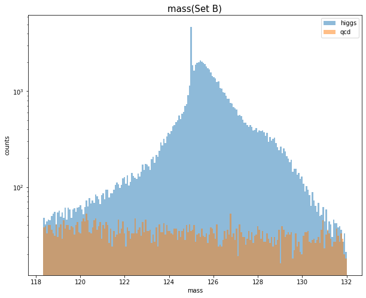

```python
plt.hist(higgs['mass'][indexh],bins=200,alpha=0.5,label='higgs')
plt.hist(qcd['mass'][indexq],bins=200,alpha=0.5,label='qcd')
plt.legend()
plt.xlabel("mass", size=10)
plt.ylabel("counts",size=10)
plt.title("mass(Set B)",size=15)
plt.yscale('log');
```

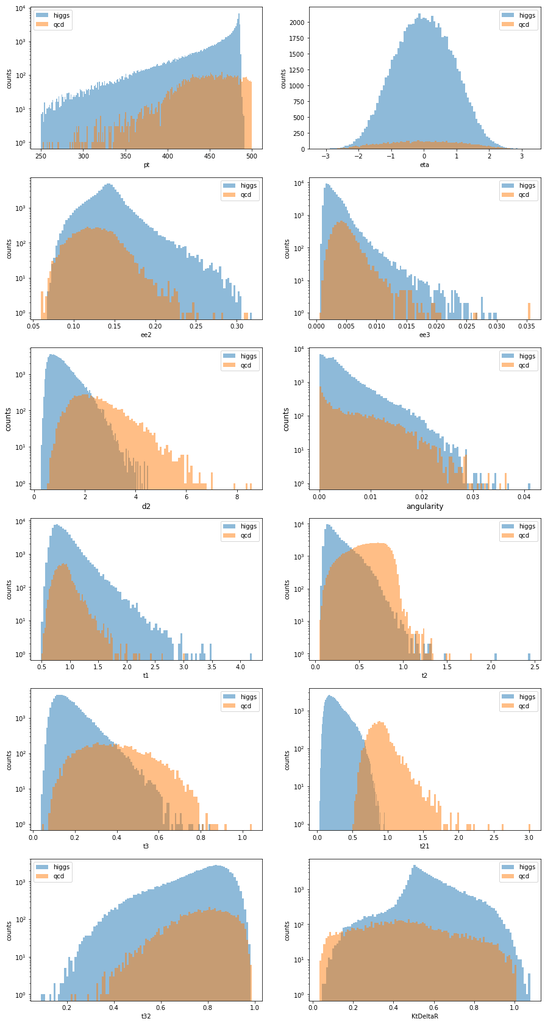

```python
fig, ax= plt.subplots(6,2,figsize=(15,30))

ax[0,0].hist(higgs['pt'][indexh],bins=200,alpha=0.5,label='higgs',stacked=True)
ax[0,0].hist(qcd['pt'][indexq],bins=200,alpha=0.5,label='qcd',stacked=True)
ax[0,0].legend()
ax[0,0].set_xlabel("pt", size=10)
ax[0,0].set_ylabel("counts",size=10)
#ax[0,0].title("Transverse Momentum(Set A)",size=15)
ax[0,0].set_yscale('log')

ax[0,1].hist(higgs['eta'][indexh],bins=100,alpha=0.5,label='higgs',stacked=True)
ax[0,1].hist(qcd['eta'][indexq],bins=100,alpha=0.5,label='qcd',stacked=True)
ax[0,1].legend()
ax[0,1].set_xlabel("eta", size=10)
ax[0,1].set_ylabel("counts",size=10)
#ax[0,1].title("eta (pseudorapidity) (Set A)",size=15);

ax[1,0].hist(higgs['ee2'][indexh],bins=100,alpha=0.5,label='higgs',stacked=True)
ax[1,0].hist(qcd['ee2'][indexq],bins=100,alpha=0.5,label='qcd',stacked=True)
ax[1,0].legend()
ax[1,0].set_xlabel("ee2", size=10)
ax[1,0].set_yscale('log')
ax[1,0].set_ylabel("counts",size=10)
#plt.title("ee2 (Set A)",size=15)

ax[1,1].hist(higgs['ee3'][indexh],bins=100,alpha=0.5,label='higgs',stacked=True)
ax[1,1].hist(qcd['ee3'][indexq],bins=100,alpha=0.5,label='qcd',stacked=True)
ax[1,1].legend()
ax[1,1].set_xlabel("ee3", size=10)
ax[1,1].set_yscale('log')
ax[1,1].set_ylabel("counts",size=10)
#plt.title("ee3 (Set A)",size=15);

ax[2,0].hist(higgs['d2'][indexh],bins=100,alpha=0.5,label='higgs',stacked=True)
ax[2,0].hist(qcd['d2'][indexq],bins=100,alpha=0.5,label='qcd',stacked=True)
ax[2,0].legend()
ax[2,0].set_xlabel("d2", size=12)
ax[2,0].set_yscale('log')
ax[2,0].set_ylabel("counts",size=12)
#ax[2,0].title("d2 (Set A)",size=15);

ax[2,1].hist(higgs['angularity'][indexh],bins=100,alpha=0.5,label='higgs',stacked=True)
ax[2,1].hist(qcd['angularity'][indexq],bins=100,alpha=0.5,label='qcd',stacked=True)
ax[2,1].legend()
ax[2,1].set_xlabel("angularity", size=12)
ax[2,1].set_yscale('log')
ax[2,1].set_ylabel("counts",size=12)
#ax[2,1].title("angularity (Set A)",size=15);


ax[3,0].hist(higgs['t1'][indexh],bins=100,alpha=0.5,label='higgs',stacked=True)
ax[3,0].hist(qcd['t1'][indexq],bins=100,alpha=0.5,label='qcd',stacked=True)
ax[3,0].legend()
ax[3,0].set_xlabel("t1", size=10)
ax[3,0].set_yscale('log')
ax[3,0].set_ylabel("counts",size=10)

ax[3,1].hist(higgs['t2'][indexh],bins=100,alpha=0.5,label='higgs',stacked=True)
ax[3,1].hist(qcd['t2'][indexh],bins=100,alpha=0.5,label='qcd',stacked=True)
ax[3,1].legend()
ax[3,1].set_xlabel("t2", size=10)
ax[3,1].set_yscale('log')
ax[3,1].set_ylabel("counts",size=10)

ax[4,0].hist(higgs['t3'][indexh],bins=100,alpha=0.5,label='higgs',stacked=True)
ax[4,0].hist(qcd['t3'][indexq],bins=100,alpha=0.5,label='qcd',stacked=True)
ax[4,0].legend()
ax[4,0].set_xlabel("t3", size=10)
ax[4,0].set_yscale('log')
ax[4,0].set_ylabel("counts",size=10)


ax[4,1].hist(higgs['t21'][indexh],bins=100,alpha=0.5,label='higgs',stacked=True)
ax[4,1].hist(qcd['t1'][indexq],bins=100,alpha=0.5,label='qcd',stacked=True)
ax[4,1].legend()
ax[4,1].set_xlabel("t21", size=10)
ax[4,1].set_yscale('log')
ax[4,1].set_ylabel("counts",size=10)


ax[5,0].hist(higgs['t32'][indexh],bins=100,alpha=0.5,label='higgs',stacked=True)
ax[5,0].hist(qcd['t32'][indexq],bins=100,alpha=0.5,label='qcd',stacked=True)
ax[5,0].legend()
ax[5,0].set_xlabel("t32", size=10)
ax[5,0].set_yscale('log')
ax[5,0].set_ylabel("counts",size=10)

ax[5,1].hist(higgs['KtDeltaR'][indexh],bins=100,alpha=0.5,label='higgs',stacked=True)
ax[5,1].hist(qcd['KtDeltaR'][indexq],bins=100,alpha=0.5,label='qcd',stacked=True)
ax[5,1].legend()
ax[5,1].set_xlabel("KtDeltaR", size=10)
ax[5,1].set_yscale('log')
ax[5,1].set_ylabel("counts",size=10)
```

##### 4. Optimize event selections using multiple features (if necessary). Find a set of feature cuts which can help you to achieve the best significance. Compare significance (before/after event selection) dervied in your pT samples to your lab partner. Describe your findings.

```python
higgsc1 = higgs[higgs.mass.between(118.33,132)]
qcdc1 = qcd[qcd.mass.between(118.33,132)]
```

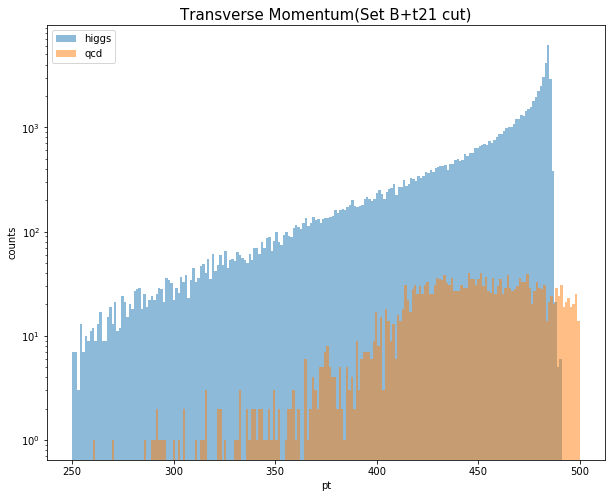

```python
higgsc2 = higgsc1[higgsc1.t21.between(0,0.5)]
qcdc2 = qcdc1[qcdc1.t21.between(0,0.5)]

plt.hist(higgsc2['pt'],bins=200,alpha=0.5,label='higgs')
plt.hist(qcdc2['pt'],bins=200,alpha=0.5,label='qcd')
plt.legend()
plt.xlabel("pt", size=10)
plt.ylabel("counts",size=10)
plt.title("Transverse Momentum(Set B+t21 cut)",size=15)
plt.yscale('log');
```

```python
Ncounth=len(higgsc2)*100/100000
Ncountq=len(qcdc2)*20000/100000
sig=Ncounth/(np.sqrt(Ncountq))
print("Adding t21 cut,𝑁𝐻𝑖𝑔𝑔𝑠/(√𝑁𝑄𝐶𝐷): {:.2f}".format(sig))
```

```
Adding t21 cut,𝑁𝐻𝑖𝑔𝑔𝑠/(√𝑁𝑄𝐶𝐷): 3.25
```

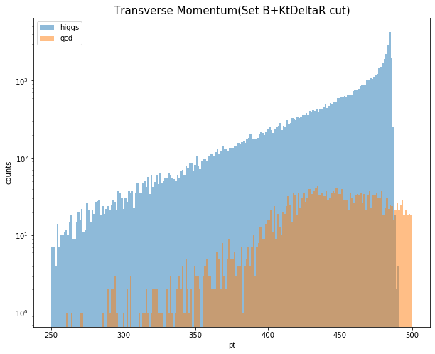

```python
higgsc3 = higgsc1[higgsc1.KtDeltaR.between(0.5,max(higgs['KtDeltaR']))]
qcdc3 = qcdc1[qcdc1.KtDeltaR.between(0.5,max(higgs['KtDeltaR']))]

plt.hist(higgsc3['pt'],bins=200,alpha=0.5,label='higgs')
plt.hist(qcdc3['pt'],bins=200,alpha=0.5,label='qcd')
plt.legend()
plt.xlabel("pt", size=10)
plt.ylabel("counts",size=10)
plt.title("Transverse Momentum(Set B+KtDeltaR cut)",size=15)
plt.yscale('log');
```

```python
Ncounth=len(higgsc3)*100/100000
Ncountq=len(qcdc3)*20000/100000
sig=Ncounth/(np.sqrt(Ncountq))
print("Adding KtDeltaR cut,𝑁𝐻𝑖𝑔𝑔𝑠/(√𝑁𝑄𝐶𝐷): {:.2f}".format(sig))
```

```
Adding KtDeltaR cut,𝑁𝐻𝑖𝑔𝑔𝑠/(√𝑁𝑄𝐶𝐷): 2.66
```

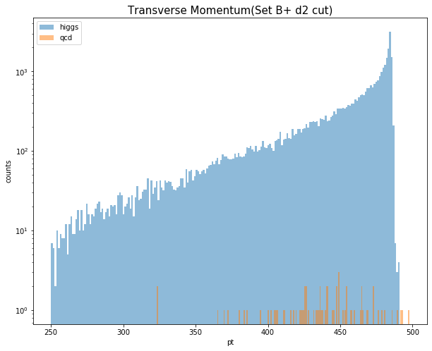

```python
higgsc4 = higgsc1[higgsc1.d2.between(min(higgs['d2']),0.95)]
qcdc4 = qcdc1[qcdc1.d2.between(min(higgs['d2']),0.95)]

plt.hist(higgsc4['pt'],bins=200,alpha=0.5,label='higgs')
plt.hist(qcdc4['pt'],bins=200,alpha=0.5,label='qcd')
plt.legend()
plt.xlabel("pt", size=10)
plt.ylabel("counts",size=10)
plt.title("Transverse Momentum(Set B+ d2 cut)",size=15)
plt.yscale('log');
```

```python
Ncounth=len(higgsc4)*100/100000
Ncountq=len(qcdc4)*20000/100000
sig=Ncounth/(np.sqrt(Ncountq))
print("Adding d2 cut,𝑁𝐻𝑖𝑔𝑔𝑠/(√𝑁𝑄𝐶𝐷): {:.2f}".format(sig))
```

```
Adding d2 cut,𝑁𝐻𝑖𝑔𝑔𝑠/(√𝑁𝑄𝐶𝐷): 10.00
```

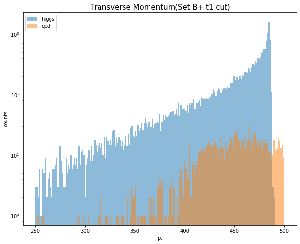

```python
higgsc5 = higgsc1[higgsc1.t1.between(1,max(higgs['t1']))]
qcdc5 = qcdc1[qcdc1.t1.between(1,max(higgs['t1']))]

plt.hist(higgsc5['pt'],bins=200,alpha=0.5,label='higgs')
plt.hist(qcdc5['pt'],bins=200,alpha=0.5,label='qcd')
plt.legend()
plt.xlabel("pt", size=10)
plt.ylabel("counts",size=10)
plt.title("Transverse Momentum(Set B+ t1 cut)",size=15)
plt.yscale('log');
```

```python
Ncounth=len(higgsc5)*100/100000
Ncountq=len(qcdc5)*20000/100000
sig=Ncounth/(np.sqrt(Ncountq))
print("Adding t1 cut,𝑁𝐻𝑖𝑔𝑔𝑠/(√𝑁𝑄𝐶𝐷): {:.2f}".format(sig))
```

```
Adding t1 cut,𝑁𝐻𝑖𝑔𝑔𝑠/(√𝑁𝑄𝐶𝐷): 1.20
```

After comparing all features, it appears that adding d2 cut was the most effective, with 𝑁𝐻𝑖𝑔𝑔𝑠/(√𝑁𝑄𝐶𝐷)=10.

## Lab8

```python
dth= pd.read_hdf('data_highlumi')
dth.shape

dtl= pd.read_hdf('data_lowlumi')
dtl.shape
```

```
(4060, 14)
```

### High Luminosity Data

#### 1. Plot observed data, overlap with expected signal and background (normalized to observed yields) without event selection.

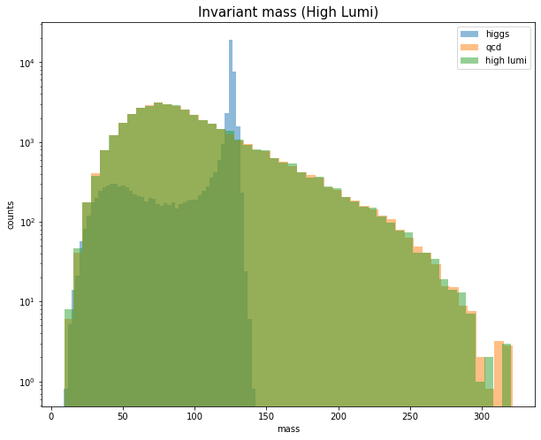

```python
weight_h=np.full(100000,40344/100000)
plt.hist(higgs['mass'],bins=50, alpha=0.5,label='higgs',stacked=True,weights=weight_h)
plt.hist(qcd['mass'],bins=50,alpha=0.5,label='qcd', stacked=True,weights=weight_h)
plt.hist(dth['mass'],bins=50,alpha=0.5,label='high lumi', stacked=True)
plt.legend()
plt.xlabel("mass", size=10)
plt.yscale('log')
plt.ylabel("counts",size=10)
plt.title("Invariant mass (High Lumi)",size=15);
```

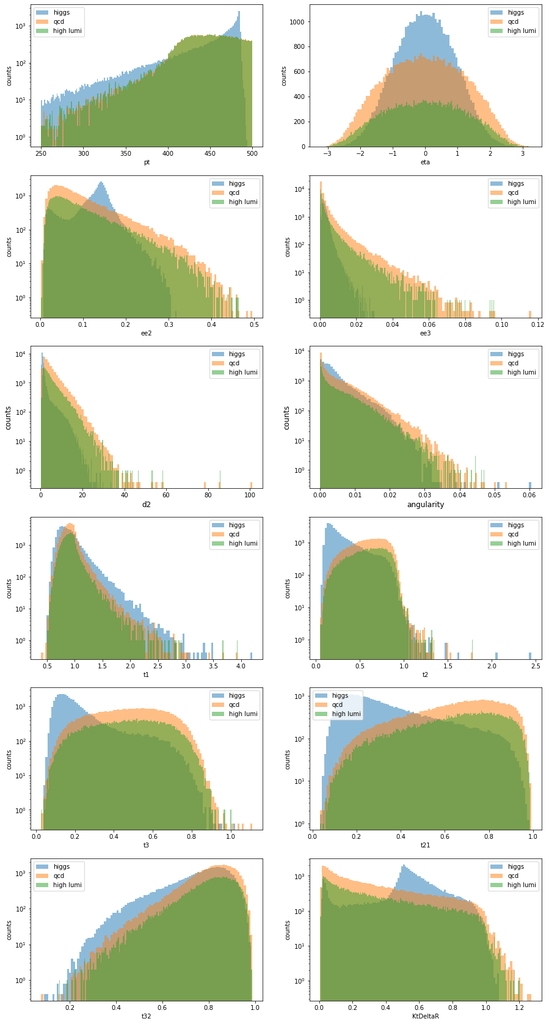

```python
fig, ax= plt.subplots(6,2,figsize=(15,30))

weight_h=np.full(100000,40344/100000)

ax[0,0].hist(higgs['pt'],bins=200,alpha=0.5,label='higgs',stacked=True,weights=weight_h)
ax[0,0].hist(qcd['pt'],bins=200,alpha=0.5,label='qcd',stacked=True,weights=weight_h)
ax[0,0].hist(dth['pt'],bins=200,alpha=0.5,label='high lumi',stacked=True)
ax[0,0].legend()
ax[0,0].set_xlabel("pt", size=10)
ax[0,0].set_ylabel("counts",size=10)
#ax[0,0].title("Transverse Momentum(Set A)",size=15)
ax[0,0].set_yscale('log')

ax[0,1].hist(higgs['eta'],bins=100,alpha=0.5,label='higgs',stacked=True,weights=weight_h)
ax[0,1].hist(qcd['eta'],bins=100,alpha=0.5,label='qcd',stacked=True,weights=weight_h)
ax[0,1].hist(dth['eta'],bins=200,alpha=0.5,label='high lumi',stacked=True)
ax[0,1].legend()
ax[0,1].set_xlabel("eta", size=10)
ax[0,1].set_ylabel("counts",size=10)
#ax[0,1].title("eta (pseudorapidity) (Set A)",size=15);

ax[1,0].hist(higgs['ee2'],bins=100,alpha=0.5,label='higgs',stacked=True,weights=weight_h)
ax[1,0].hist(qcd['ee2'],bins=100,alpha=0.5,label='qcd',stacked=True,weights=weight_h)
ax[1,0].hist(dth['ee2'],bins=200,alpha=0.5,label='high lumi',stacked=True)
ax[1,0].legend()
ax[1,0].set_xlabel("ee2", size=10)
ax[1,0].set_yscale('log')
ax[1,0].set_ylabel("counts",size=10)
#plt.title("ee2 (Set A)",size=15)

ax[1,1].hist(higgs['ee3'],bins=100,alpha=0.5,label='higgs',stacked=True,weights=weight_h)
ax[1,1].hist(qcd['ee3'],bins=100,alpha=0.5,label='qcd',stacked=True,weights=weight_h)
ax[1,1].hist(dth['ee3'],bins=200,alpha=0.5,label='high lumi',stacked=True)
ax[1,1].legend()
ax[1,1].set_xlabel("ee3", size=10)
ax[1,1].set_yscale('log')
ax[1,1].set_ylabel("counts",size=10)
#plt.title("ee3 (Set A)",size=15);

ax[2,0].hist(higgs['d2'],bins=100,alpha=0.5,label='higgs',stacked=True,weights=weight_h)
ax[2,0].hist(qcd['d2'],bins=100,alpha=0.5,label='qcd',stacked=True,weights=weight_h)
ax[2,0].hist(dth['d2'],bins=200,alpha=0.5,label='high lumi',stacked=True)
ax[2,0].legend()
ax[2,0].set_xlabel("d2", size=12)
ax[2,0].set_yscale('log')

ax[2,0].set_ylabel("counts",size=12)
#ax[2,0].title("d2 (Set A)",size=15);

ax[2,1].hist(higgs['angularity'],bins=100,alpha=0.5,label='higgs',stacked=True,weights=weight_h)
ax[2,1].hist(qcd['angularity'],bins=100,alpha=0.5,label='qcd',stacked=True,weights=weight_h)
ax[2,1].hist(dth['angularity'],bins=200,alpha=0.5,label='high lumi',stacked=True)
ax[2,1].legend()
ax[2,1].set_xlabel("angularity", size=12)
ax[2,1].set_yscale('log')
ax[2,1].set_ylabel("counts",size=12)
#ax[2,1].title("angularity (Set A)",size=15);


ax[3,0].hist(higgs['t1'],bins=100,alpha=0.5,label='higgs',stacked=True,weights=weight_h)
ax[3,0].hist(qcd['t1'],bins=100,alpha=0.5,label='qcd',stacked=True,weights=weight_h)
ax[3,0].hist(dth['t1'],bins=200,alpha=0.5,label='high lumi',stacked=True)
ax[3,0].legend()
ax[3,0].set_xlabel("t1", size=10)
ax[3,0].set_yscale('log')
ax[3,0].set_ylabel("counts",size=10)

ax[3,1].hist(higgs['t2'],bins=100,alpha=0.5,label='higgs',stacked=True,weights=weight_h)
ax[3,1].hist(qcd['t2'],bins=100,alpha=0.5,label='qcd',stacked=True,weights=weight_h)
ax[3,1].hist(dth['t2'],bins=200,alpha=0.5,label='high lumi',stacked=True)
ax[3,1].legend()
ax[3,1].set_xlabel("t2", size=10)
ax[3,1].set_yscale('log')
ax[3,1].set_ylabel("counts",size=10)

ax[4,0].hist(higgs['t3'],bins=100,alpha=0.5,label='higgs',stacked=True,weights=weight_h)
ax[4,0].hist(qcd['t3'],bins=100,alpha=0.5,label='qcd',stacked=True,weights=weight_h)
ax[4,0].hist(dth['t3'],bins=200,alpha=0.5,label='high lumi',stacked=True)
ax[4,0].legend()
ax[4,0].set_xlabel("t3", size=10)
ax[4,0].set_yscale('log')
ax[4,0].set_ylabel("counts",size=10)


ax[4,1].hist(higgs['t21'],bins=100,alpha=0.5,label='higgs',stacked=True,weights=weight_h)
ax[4,1].hist(qcd['t21'],bins=100,alpha=0.5,label='qcd',stacked=True,weights=weight_h)
ax[4,1].hist(dth['t21'],bins=200,alpha=0.5,label='high lumi',stacked=True)
ax[4,1].legend()
ax[4,1].set_xlabel("t21", size=10)
ax[4,1].set_yscale('log')
ax[4,1].set_ylabel("counts",size=10)


ax[5,0].hist(higgs['t32'],bins=100,alpha=0.5,label='higgs',stacked=True,weights=weight_h)
ax[5,0].hist(qcd['t32'],bins=100,alpha=0.5,label='qcd',stacked=True,weights=weight_h)
ax[5,0].hist(dth['t32'],bins=200,alpha=0.5,label='high lumi',stacked=True)
ax[5,0].legend()
ax[5,0].set_xlabel("t32", size=10)
ax[5,0].set_yscale('log')
ax[5,0].set_ylabel("counts",size=10)

ax[5,1].hist(higgs['KtDeltaR'],bins=100,alpha=0.5,label='higgs',stacked=True,weights=weight_h)
ax[5,1].hist(qcd['KtDeltaR'],bins=100,alpha=0.5,label='qcd',stacked=True,weights=weight_h)
ax[5,1].hist(dth['KtDeltaR'],bins=200,alpha=0.5,label='high lumi',stacked=True)
ax[5,1].legend()
ax[5,1].set_xlabel("KtDeltaR", size=10)
ax[5,1].set_yscale('log')
ax[5,1].set_ylabel("counts",size=10)
```

#### 2. Plot observed data, overlap with expected signal and background (normalized to observed yields) with optimal event selection.

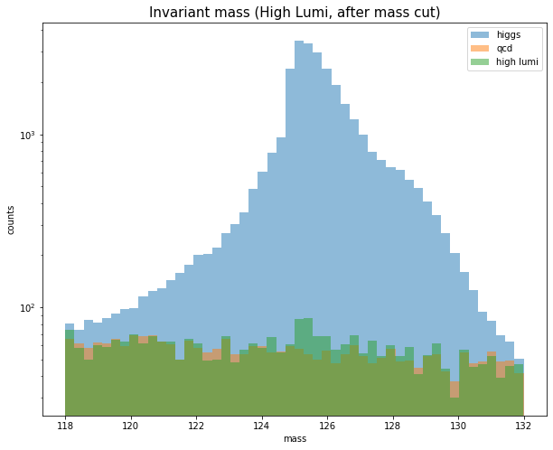

```python
higgsc1= higgs[higgs.mass.between(118,132)]
qcdc1= qcd[qcd.mass.between(118,132)]
dthc1= dth[dth.mass.between(118,132)]

weight_hh=np.full(len(higgsc1),40344/100000)
weight_hq=np.full(len(qcdc1),40344/100000)


plt.hist(higgsc1['mass'],bins=50, alpha=0.5,label='higgs',stacked=True,weights=weight_hh)
plt.hist(qcdc1['mass'],bins=50,alpha=0.5,label='qcd', stacked=True,weights=weight_hq)
plt.hist(dthc1['mass'],bins=50,alpha=0.5,label='high lumi', stacked=True)
plt.legend()
plt.xlabel("mass", size=10)
plt.yscale('log')
plt.ylabel("counts",size=10)
plt.title("Invariant mass (High Lumi, after mass cut)",size=15);
```

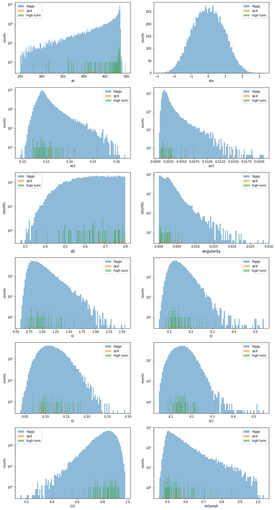

```python
fig, ax= plt.subplots(6,2,figsize=(15,30))

higgs_masked=higgsc1[higgsc1.d2.between(min(higgs['d2']),0.8)]
qcd_masked=qcdc1[qcdc1.d2.between(min(higgs['d2']),0.8)]
dth_masked=dthc1[dthc1.d2.between(min(higgs['d2']),0.8)]

# higgs_masked=higgsc1[higgsc1.t21.between(0,0.3)]
# qcd_masked=qcdc1[qcdc1.t21.between(0,0.3)]
# dth_masked=dthc1[dthc1.t21.between(0,0.3)]

# higgs_masked=higgsc1
# qcd_masked=qcdc1
# dth_masked=dthc1


weight_hh=np.full(len(higgs_masked),40344/100000)
weight_hq=np.full(len(qcd_masked),40344/100000)

ax[0,0].hist(higgs_masked['pt'],bins=200,alpha=0.5,label='higgs',stacked=True,weights=weight_hh)
ax[0,0].hist(qcd_masked['pt'],bins=200,alpha=0.5,label='qcd',stacked=True,weights=weight_hq)
ax[0,0].hist(dth_masked['pt'],bins=200,alpha=0.5,label='high lumi',stacked=True)
ax[0,0].legend()
ax[0,0].set_xlabel("pt", size=10)
ax[0,0].set_ylabel("counts",size=10)
#ax[0,0].title("Transverse Momentum(Set A)",size=15)
ax[0,0].set_yscale('log')

ax[0,1].hist(higgs_masked['eta'],bins=100,alpha=0.5,label='higgs',stacked=True,weights=weight_hh)
ax[0,1].hist(qcd_masked['eta'],bins=100,alpha=0.5,label='qcd',stacked=True,weights=weight_hq)
ax[0,1].hist(dth_masked['eta'],bins=200,alpha=0.5,label='high lumi',stacked=True)
ax[0,1].legend()
ax[0,1].set_xlabel("eta", size=10)
ax[0,1].set_ylabel("counts",size=10)
#ax[0,1].title("eta (pseudorapidity) (Set A)",size=15);

ax[1,0].hist(higgs_masked['ee2'],bins=100,alpha=0.5,label='higgs',stacked=True,weights=weight_hh)
ax[1,0].hist(qcd_masked['ee2'],bins=100,alpha=0.5,label='qcd',stacked=True,weights=weight_hq)
ax[1,0].hist(dth_masked['ee2'],bins=200,alpha=0.5,label='high lumi',stacked=True)
ax[1,0].legend()
ax[1,0].set_xlabel("ee2", size=10)
ax[1,0].set_yscale('log')
ax[1,0].set_ylabel("counts",size=10)
#plt.title("ee2 (Set A)",size=15)

ax[1,1].hist(higgs_masked['ee3'],bins=100,alpha=0.5,label='higgs',stacked=True,weights=weight_hh)
ax[1,1].hist(qcd_masked['ee3'],bins=100,alpha=0.5,label='qcd',stacked=True,weights=weight_hq)
ax[1,1].hist(dth_masked['ee3'],bins=200,alpha=0.5,label='high lumi',stacked=True)
ax[1,1].legend()
ax[1,1].set_xlabel("ee3", size=10)
ax[1,1].set_yscale('log')
ax[1,1].set_ylabel("counts",size=10)
#plt.title("ee3 (Set A)",size=15);

ax[2,0].hist(higgs_masked['d2'],bins=100,alpha=0.5,label='higgs',stacked=True,weights=weight_hh)
ax[2,0].hist(qcd_masked['d2'],bins=100,alpha=0.5,label='qcd',stacked=True,weights=weight_hq)
ax[2,0].hist(dth_masked['d2'],bins=200,alpha=0.5,label='high lumi',stacked=True)
ax[2,0].legend()
ax[2,0].set_xlabel("d2", size=12)
ax[2,0].set_yscale('log')
ax[2,0].set_ylabel("counts",size=12)
#ax[2,0].title("d2 (Set A)",size=15);

ax[2,1].hist(higgs_masked['angularity'],bins=100,alpha=0.5,label='higgs',stacked=True,weights=weight_hh)
ax[2,1].hist(qcd_masked['angularity'],bins=100,alpha=0.5,label='qcd',stacked=True,weights=weight_hq)
ax[2,1].hist(dth_masked['angularity'],bins=200,alpha=0.5,label='high lumi',stacked=True)
ax[2,1].legend()
ax[2,1].set_xlabel("angularity", size=12)
ax[2,1].set_yscale('log')
ax[2,1].set_ylabel("counts",size=12)
#ax[2,1].title("angularity (Set A)",size=15);


ax[3,0].hist(higgs_masked['t1'],bins=100,alpha=0.5,label='higgs',stacked=True,weights=weight_hh)
ax[3,0].hist(qcd_masked['t1'],bins=100,alpha=0.5,label='qcd',stacked=True,weights=weight_hq)
ax[3,0].hist(dth_masked['t1'],bins=200,alpha=0.5,label='high lumi',stacked=True)
ax[3,0].legend()
ax[3,0].set_xlabel("t1", size=10)
ax[3,0].set_yscale('log')
ax[3,0].set_ylabel("counts",size=10)

ax[3,1].hist(higgs_masked['t2'],bins=100,alpha=0.5,label='higgs',stacked=True,weights=weight_hh)
ax[3,1].hist(qcd_masked['t2'],bins=100,alpha=0.5,label='qcd',stacked=True,weights=weight_hq)
ax[3,1].hist(dth_masked['t2'],bins=200,alpha=0.5,label='high lumi',stacked=True)
ax[3,1].legend()
ax[3,1].set_xlabel("t2", size=10)
ax[3,1].set_yscale('log')
ax[3,1].set_ylabel("counts",size=10)

ax[4,0].hist(higgs_masked['t3'],bins=100,alpha=0.5,label='higgs',stacked=True,weights=weight_hh)
ax[4,0].hist(qcd_masked['t3'],bins=100,alpha=0.5,label='qcd',stacked=True,weights=weight_hq)
ax[4,0].hist(dth_masked['t3'],bins=200,alpha=0.5,label='high lumi',stacked=True)
ax[4,0].legend()
ax[4,0].set_xlabel("t3", size=10)
ax[4,0].set_yscale('log')
ax[4,0].set_ylabel("counts",size=10)


ax[4,1].hist(higgs_masked['t21'],bins=100,alpha=0.5,label='higgs',stacked=True,weights=weight_hh)
ax[4,1].hist(qcd_masked['t21'],bins=100,alpha=0.5,label='qcd',stacked=True,weights=weight_hq)
ax[4,1].hist(dth_masked['t21'],bins=200,alpha=0.5,label='high lumi',stacked=True)
ax[4,1].legend()
ax[4,1].set_xlabel("t21", size=10)
ax[4,1].set_yscale('log')
ax[4,1].set_ylabel("counts",size=10)


ax[5,0].hist(higgs_masked['t32'],bins=100,alpha=0.5,label='higgs',stacked=True,weights=weight_hh)
ax[5,0].hist(qcd_masked['t32'],bins=100,alpha=0.5,label='qcd',stacked=True,weights=weight_hq)
ax[5,0].hist(dth_masked['t32'],bins=200,alpha=0.5,label='high lumi',stacked=True)
ax[5,0].legend()
ax[5,0].set_xlabel("t32", size=10)
ax[5,0].set_yscale('log')
ax[5,0].set_ylabel("counts",size=10)

ax[5,1].hist(higgs_masked['KtDeltaR'],bins=100,alpha=0.5,label='higgs',stacked=True,weights=weight_hh)
ax[5,1].hist(qcd_masked['KtDeltaR'],bins=100,alpha=0.5,label='qcd',stacked=True,weights=weight_hq)
ax[5,1].hist(dth_masked['KtDeltaR'],bins=200,alpha=0.5,label='high lumi',stacked=True)
ax[5,1].legend()
ax[5,1].set_xlabel("KtDeltaR", size=10)
ax[5,1].set_yscale('log')
ax[5,1].set_ylabel("counts",size=10);
```

#### 3. Evaluate observed significance and compare your results to expectation

```python
Ncounth=len(higgs_masked)*(100/100000)
Ncountq=len(qcd_masked)*(20000/100000)
Ncountdh=len(higgs_masked)*(100/20000)*(40344/100000)
Ncountd=len(dth_masked)
sig_ex=Ncounth/(np.sqrt(Ncountq))
sig_ob=Ncountdh/(np.sqrt(Ncountd))
print("After optimal selection, the expected significance 𝑁𝐻𝑖𝑔𝑔𝑠/(√𝑁𝑄𝐶𝐷) is {:.2f}".format(sig_ex))
print("After optimal selection, the observed significance 𝑁𝐻𝑖𝑔𝑔𝑠/(√𝑁𝑄𝐶𝐷) is {:.2f}".format(sig_ob))
```

```
After optimal selection, the expected significance 𝑁𝐻𝑖𝑔𝑔𝑠/(√𝑁𝑄𝐶𝐷) is 13.14
After optimal selection, the observed significance 𝑁𝐻𝑖𝑔𝑔𝑠/(√𝑁𝑄𝐶𝐷) is 6.38
```

### Low Luminosity

#### 1. Plot observed data, overlap with expected signal and background (normalized to observed yields) without event selection.

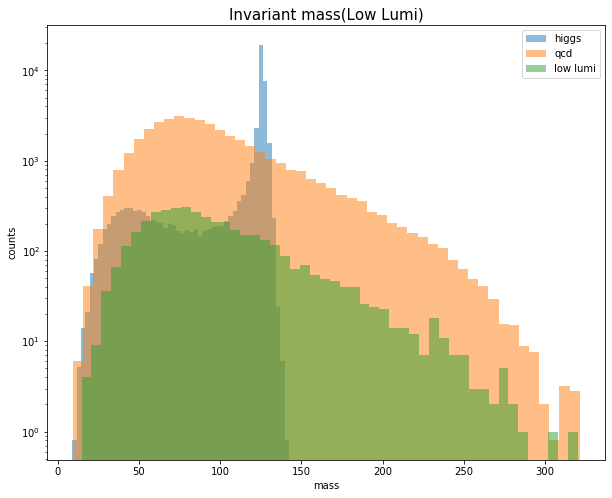

```python
weight_h=np.full(100000,40344/100000)
plt.hist(higgs['mass'],bins=50, alpha=0.5,label='higgs',stacked=True,weights=weight_h)
plt.hist(qcd['mass'],bins=50,alpha=0.5,label='qcd', stacked=True,weights=weight_h)
plt.hist(dtl['mass'],bins=50,alpha=0.5,label='low lumi', stacked=True)
plt.legend()
plt.xlabel("mass", size=10)
plt.yscale('log')
plt.ylabel("counts",size=10)
plt.title("Invariant mass(Low Lumi)",size=15);
```

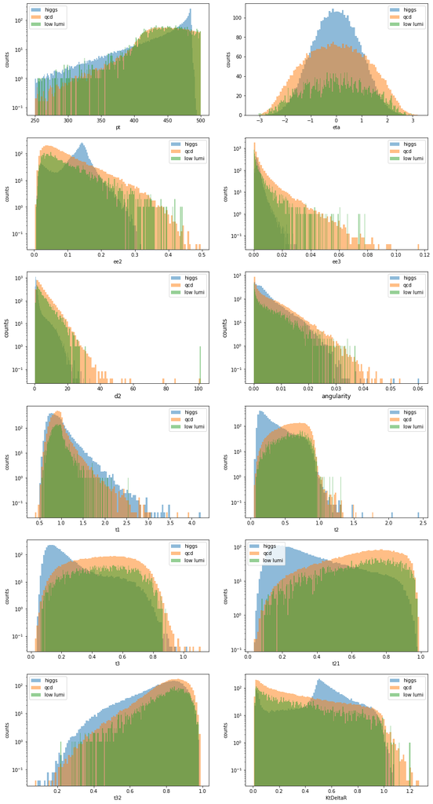

```python
fig, ax= plt.subplots(6,2,figsize=(15,30))

weight_h=np.full(100000,4060/100000)

ax[0,0].hist(higgs['pt'],bins=200,alpha=0.5,label='higgs',stacked=True,weights=weight_h)
ax[0,0].hist(qcd['pt'],bins=200,alpha=0.5,label='qcd',stacked=True,weights=weight_h)
ax[0,0].hist(dtl['pt'],bins=200,alpha=0.5,label='low lumi',stacked=True)
ax[0,0].legend()
ax[0,0].set_xlabel("pt", size=10)
ax[0,0].set_ylabel("counts",size=10)
#ax[0,0].title("Transverse Momentum(Set A)",size=15)
ax[0,0].set_yscale('log')

ax[0,1].hist(higgs['eta'],bins=100,alpha=0.5,label='higgs',stacked=True,weights=weight_h)
ax[0,1].hist(qcd['eta'],bins=100,alpha=0.5,label='qcd',stacked=True,weights=weight_h)
ax[0,1].hist(dtl['eta'],bins=200,alpha=0.5,label='low lumi',stacked=True)
ax[0,1].legend()
ax[0,1].set_xlabel("eta", size=10)
ax[0,1].set_ylabel("counts",size=10)
#ax[0,1].title("eta (pseudorapidity) (Set A)",size=15);

ax[1,0].hist(higgs['ee2'],bins=100,alpha=0.5,label='higgs',stacked=True,weights=weight_h)
ax[1,0].hist(qcd['ee2'],bins=100,alpha=0.5,label='qcd',stacked=True,weights=weight_h)
ax[1,0].hist(dtl['ee2'],bins=200,alpha=0.5,label='low lumi',stacked=True)
ax[1,0].legend()
ax[1,0].set_xlabel("ee2", size=10)
ax[1,0].set_yscale('log')
ax[1,0].set_ylabel("counts",size=10)
#plt.title("ee2 (Set A)",size=15)

ax[1,1].hist(higgs['ee3'],bins=100,alpha=0.5,label='higgs',stacked=True,weights=weight_h)
ax[1,1].hist(qcd['ee3'],bins=100,alpha=0.5,label='qcd',stacked=True,weights=weight_h)
ax[1,1].hist(dtl['ee3'],bins=200,alpha=0.5,label='low lumi',stacked=True)
ax[1,1].legend()
ax[1,1].set_xlabel("ee3", size=10)
ax[1,1].set_yscale('log')
ax[1,1].set_ylabel("counts",size=10)
#plt.title("ee3 (Set A)",size=15);

ax[2,0].hist(higgs['d2'],bins=100,alpha=0.5,label='higgs',stacked=True,weights=weight_h)
ax[2,0].hist(qcd['d2'],bins=100,alpha=0.5,label='qcd',stacked=True,weights=weight_h)
ax[2,0].hist(dtl['d2'],bins=200,alpha=0.5,label='low lumi',stacked=True)
ax[2,0].legend()
ax[2,0].set_xlabel("d2", size=12)
ax[2,0].set_yscale('log')

ax[2,0].set_ylabel("counts",size=12)
#ax[2,0].title("d2 (Set A)",size=15);

ax[2,1].hist(higgs['angularity'],bins=100,alpha=0.5,label='higgs',stacked=True,weights=weight_h)
ax[2,1].hist(qcd['angularity'],bins=100,alpha=0.5,label='qcd',stacked=True,weights=weight_h)
ax[2,1].hist(dtl['angularity'],bins=200,alpha=0.5,label='low lumi',stacked=True)
ax[2,1].legend()
ax[2,1].set_xlabel("angularity", size=12)
ax[2,1].set_yscale('log')
ax[2,1].set_ylabel("counts",size=12)
#ax[2,1].title("angularity (Set A)",size=15);


ax[3,0].hist(higgs['t1'],bins=100,alpha=0.5,label='higgs',stacked=True,weights=weight_h)
ax[3,0].hist(qcd['t1'],bins=100,alpha=0.5,label='qcd',stacked=True,weights=weight_h)
ax[3,0].hist(dtl['t1'],bins=200,alpha=0.5,label='low lumi',stacked=True)
ax[3,0].legend()
ax[3,0].set_xlabel("t1", size=10)
ax[3,0].set_yscale('log')
ax[3,0].set_ylabel("counts",size=10)

ax[3,1].hist(higgs['t2'],bins=100,alpha=0.5,label='higgs',stacked=True,weights=weight_h)
ax[3,1].hist(qcd['t2'],bins=100,alpha=0.5,label='qcd',stacked=True,weights=weight_h)
ax[3,1].hist(dtl['t2'],bins=200,alpha=0.5,label='low lumi',stacked=True)
ax[3,1].legend()
ax[3,1].set_xlabel("t2", size=10)
ax[3,1].set_yscale('log')
ax[3,1].set_ylabel("counts",size=10)

ax[4,0].hist(higgs['t3'],bins=100,alpha=0.5,label='higgs',stacked=True,weights=weight_h)
ax[4,0].hist(qcd['t3'],bins=100,alpha=0.5,label='qcd',stacked=True,weights=weight_h)
ax[4,0].hist(dtl['t3'],bins=200,alpha=0.5,label='low lumi',stacked=True)
ax[4,0].legend()
ax[4,0].set_xlabel("t3", size=10)
ax[4,0].set_yscale('log')
ax[4,0].set_ylabel("counts",size=10)


ax[4,1].hist(higgs['t21'],bins=100,alpha=0.5,label='higgs',stacked=True,weights=weight_h)
ax[4,1].hist(qcd['t21'],bins=100,alpha=0.5,label='qcd',stacked=True,weights=weight_h)
ax[4,1].hist(dtl['t21'],bins=200,alpha=0.5,label='low lumi',stacked=True)
ax[4,1].legend()
ax[4,1].set_xlabel("t21", size=10)
ax[4,1].set_yscale('log')
ax[4,1].set_ylabel("counts",size=10)


ax[5,0].hist(higgs['t32'],bins=100,alpha=0.5,label='higgs',stacked=True,weights=weight_h)
ax[5,0].hist(qcd['t32'],bins=100,alpha=0.5,label='qcd',stacked=True,weights=weight_h)
ax[5,0].hist(dtl['t32'],bins=200,alpha=0.5,label='low lumi',stacked=True)
ax[5,0].legend()
ax[5,0].set_xlabel("t32", size=10)
ax[5,0].set_yscale('log')
ax[5,0].set_ylabel("counts",size=10)

ax[5,1].hist(higgs['KtDeltaR'],bins=100,alpha=0.5,label='higgs',stacked=True,weights=weight_h)
ax[5,1].hist(qcd['KtDeltaR'],bins=100,alpha=0.5,label='qcd',stacked=True,weights=weight_h)
ax[5,1].hist(dtl['KtDeltaR'],bins=200,alpha=0.5,label='low lumi',stacked=True)
ax[5,1].legend()
ax[5,1].set_xlabel("KtDeltaR", size=10)
ax[5,1].set_yscale('log')
ax[5,1].set_ylabel("counts",size=10)
```

#### 2. Plot observed data, overlap with expected signal and background (normalized to observed yields) with optimal event selection.

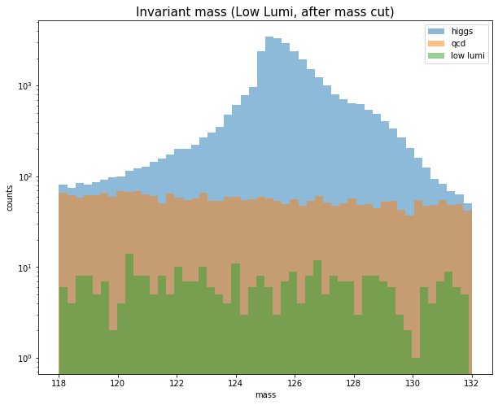

```python
higgsc1= higgs[higgs.mass.between(118,132)]
qcdc1= qcd[qcd.mass.between(118,132)]
dtlc1= dtl[dtl.mass.between(118,132)]

weight_hh=np.full(len(higgsc1),40344/100000)
weight_hq=np.full(len(qcdc1),40344/100000)


plt.hist(higgsc1['mass'],bins=50, alpha=0.5,label='higgs',stacked=True,weights=weight_hh)
plt.hist(qcdc1['mass'],bins=50,alpha=0.5,label='qcd', stacked=True,weights=weight_hq)
plt.hist(dtlc1['mass'],bins=50,alpha=0.5,label='low lumi', stacked=True)
plt.legend()
plt.xlabel("mass", size=10)
plt.yscale('log')
plt.ylabel("counts",size=10)
plt.title("Invariant mass (Low Lumi, after mass cut)",size=15);
```

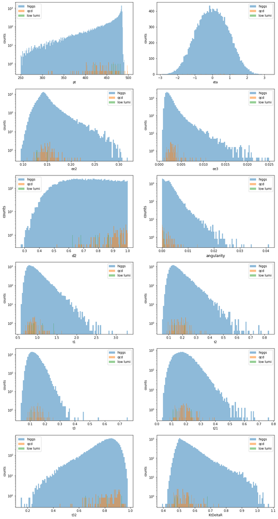

```python
fig, ax= plt.subplots(6,2,figsize=(15,30))

higgsl_masked=higgsc1[higgsc1.d2.between(min(higgs['d2']),1)]
qcdl_masked=qcdc1[qcdc1.d2.between(min(higgs['d2']),1)]
dtl_masked=dtlc1[dtlc1.d2.between(min(higgs['d2']),1)]

# higgs_masked=higgsc1[higgsc1.t21.between(0,0.3)]
# qcd_masked=qcdc1[qcdc1.t21.between(0,0.3)]
# dtl_masked=dtlc1[dtlc1.t21.between(0,0.3)]

# higgs_masked=higgsc1
# qcd_masked=qcdc1
# dth_masked=dthc1


weight_hh=np.full(len(higgsl_masked),40344/100000)
weight_hq=np.full(len(qcdl_masked),40344/100000)

ax[0,0].hist(higgsl_masked['pt'],bins=200,alpha=0.5,label='higgs',stacked=True,weights=weight_hh)
ax[0,0].hist(qcdl_masked['pt'],bins=200,alpha=0.5,label='qcd',stacked=True,weights=weight_hq)
ax[0,0].hist(dtl_masked['pt'],bins=200,alpha=0.5,label='low lumi',stacked=True)
ax[0,0].legend()
ax[0,0].set_xlabel("pt", size=10)
ax[0,0].set_ylabel("counts",size=10)
#ax[0,0].title("Transverse Momentum(Set A)",size=15)
ax[0,0].set_yscale('log')

ax[0,1].hist(higgsl_masked['eta'],bins=100,alpha=0.5,label='higgs',stacked=True,weights=weight_hh)
ax[0,1].hist(qcdl_masked['eta'],bins=100,alpha=0.5,label='qcd',stacked=True,weights=weight_hq)
ax[0,1].hist(dtl_masked['eta'],bins=200,alpha=0.5,label='low lumi',stacked=True)
ax[0,1].legend()
ax[0,1].set_xlabel("eta", size=10)
ax[0,1].set_ylabel("counts",size=10)
#ax[0,1].title("eta (pseudorapidity) (Set A)",size=15);

ax[1,0].hist(higgsl_masked['ee2'],bins=100,alpha=0.5,label='higgs',stacked=True,weights=weight_hh)
ax[1,0].hist(qcdl_masked['ee2'],bins=100,alpha=0.5,label='qcd',stacked=True,weights=weight_hq)
ax[1,0].hist(dtl_masked['ee2'],bins=200,alpha=0.5,label='low lumi',stacked=True)
ax[1,0].legend()
ax[1,0].set_xlabel("ee2", size=10)
ax[1,0].set_yscale('log')
ax[1,0].set_ylabel("counts",size=10)
#plt.title("ee2 (Set A)",size=15)

ax[1,1].hist(higgsl_masked['ee3'],bins=100,alpha=0.5,label='higgs',stacked=True,weights=weight_hh)
ax[1,1].hist(qcdl_masked['ee3'],bins=100,alpha=0.5,label='qcd',stacked=True,weights=weight_hq)
ax[1,1].hist(dtl_masked['ee3'],bins=200,alpha=0.5,label='low lumi',stacked=True)
ax[1,1].legend()
ax[1,1].set_xlabel("ee3", size=10)
ax[1,1].set_yscale('log')
ax[1,1].set_ylabel("counts",size=10)
#plt.title("ee3 (Set A)",size=15);

ax[2,0].hist(higgsl_masked['d2'],bins=100,alpha=0.5,label='higgs',stacked=True,weights=weight_hh)
ax[2,0].hist(qcdl_masked['d2'],bins=100,alpha=0.5,label='qcd',stacked=True,weights=weight_hq)
ax[2,0].hist(dtl_masked['d2'],bins=200,alpha=0.5,label='low lumi',stacked=True)
ax[2,0].legend()
ax[2,0].set_xlabel("d2", size=12)
ax[2,0].set_yscale('log')
ax[2,0].set_ylabel("counts",size=12)
#ax[2,0].title("d2 (Set A)",size=15);

ax[2,1].hist(higgsl_masked['angularity'],bins=100,alpha=0.5,label='higgs',stacked=True,weights=weight_hh)
ax[2,1].hist(qcdl_masked['angularity'],bins=100,alpha=0.5,label='qcd',stacked=True,weights=weight_hq)
ax[2,1].hist(dtl_masked['angularity'],bins=200,alpha=0.5,label='low lumi',stacked=True)
ax[2,1].legend()
ax[2,1].set_xlabel("angularity", size=12)
ax[2,1].set_yscale('log')
ax[2,1].set_ylabel("counts",size=12)
#ax[2,1].title("angularity (Set A)",size=15);


ax[3,0].hist(higgsl_masked['t1'],bins=100,alpha=0.5,label='higgs',stacked=True,weights=weight_hh)
ax[3,0].hist(qcdl_masked['t1'],bins=100,alpha=0.5,label='qcd',stacked=True,weights=weight_hq)
ax[3,0].hist(dtl_masked['t1'],bins=200,alpha=0.5,label='low lumi',stacked=True)
ax[3,0].legend()
ax[3,0].set_xlabel("t1", size=10)
ax[3,0].set_yscale('log')
ax[3,0].set_ylabel("counts",size=10)

ax[3,1].hist(higgsl_masked['t2'],bins=100,alpha=0.5,label='higgs',stacked=True,weights=weight_hh)
ax[3,1].hist(qcdl_masked['t2'],bins=100,alpha=0.5,label='qcd',stacked=True,weights=weight_hq)
ax[3,1].hist(dtl_masked['t2'],bins=200,alpha=0.5,label='low lumi',stacked=True)
ax[3,1].legend()
ax[3,1].set_xlabel("t2", size=10)
ax[3,1].set_yscale('log')
ax[3,1].set_ylabel("counts",size=10)

ax[4,0].hist(higgsl_masked['t3'],bins=100,alpha=0.5,label='higgs',stacked=True,weights=weight_hh)
ax[4,0].hist(qcdl_masked['t3'],bins=100,alpha=0.5,label='qcd',stacked=True,weights=weight_hq)
ax[4,0].hist(dtl_masked['t3'],bins=200,alpha=0.5,label='low lumi',stacked=True)
ax[4,0].legend()
ax[4,0].set_xlabel("t3", size=10)
ax[4,0].set_yscale('log')
ax[4,0].set_ylabel("counts",size=10)


ax[4,1].hist(higgsl_masked['t21'],bins=100,alpha=0.5,label='higgs',stacked=True,weights=weight_hh)
ax[4,1].hist(qcdl_masked['t21'],bins=100,alpha=0.5,label='qcd',stacked=True,weights=weight_hq)
ax[4,1].hist(dtl_masked['t21'],bins=200,alpha=0.5,label='low lumi',stacked=True)
ax[4,1].legend()
ax[4,1].set_xlabel("t21", size=10)
ax[4,1].set_yscale('log')
ax[4,1].set_ylabel("counts",size=10)


ax[5,0].hist(higgsl_masked['t32'],bins=100,alpha=0.5,label='higgs',stacked=True,weights=weight_hh)
ax[5,0].hist(qcdl_masked['t32'],bins=100,alpha=0.5,label='qcd',stacked=True,weights=weight_hq)
ax[5,0].hist(dtl_masked['t32'],bins=200,alpha=0.5,label='low lumi',stacked=True)
ax[5,0].legend()
ax[5,0].set_xlabel("t32", size=10)
ax[5,0].set_yscale('log')
ax[5,0].set_ylabel("counts",size=10)

ax[5,1].hist(higgsl_masked['KtDeltaR'],bins=100,alpha=0.5,label='higgs',stacked=True,weights=weight_hh)
ax[5,1].hist(qcdl_masked['KtDeltaR'],bins=100,alpha=0.5,label='qcd',stacked=True,weights=weight_hq)
ax[5,1].hist(dtl_masked['KtDeltaR'],bins=200,alpha=0.5,label='low lumi',stacked=True)
ax[5,1].legend()
ax[5,1].set_xlabel("KtDeltaR", size=10)
ax[5,1].set_yscale('log')
ax[5,1].set_ylabel("counts",size=10);
```

#### Evaluate observed significance and compare your results to expectation

```python
Ncounth=len(higgsl_masked)*(100/20000)*(4060/100000)
Ncountq=len(qcdl_masked)*(4060/100000)
Ncountd=len(dtl_masked)
sig_ex=Ncounth/(np.sqrt(Ncountq))
sig_ob=Ncounth/(np.sqrt(Ncountd))
print("After optimal selection, the expected significance 𝑁𝐻𝑖𝑔𝑔𝑠/(√𝑁𝑄𝐶𝐷) is {:.2f}".format(sig_ex))
print("After optimal selection, the observed significance 𝑁𝐻𝑖𝑔𝑔𝑠/(√𝑁𝑄𝐶𝐷) is {:.2f}".format(sig_ob))
```

```
After optimal selection, the expected significance 𝑁𝐻𝑖𝑔𝑔𝑠/(√𝑁𝑄𝐶𝐷) is 4.05
After optimal selection, the observed significance 𝑁𝐻𝑖𝑔𝑔𝑠/(√𝑁𝑄𝐶𝐷) is 2.79
```

The observed siginifance is smaller than expected significance.

### 95% Confidence Level of signal yields

##### In the low luminosity data, the observed significance is less than 5 𝜎 . We will calculate the 95% confidence level upper limit of signal yield.

##### Evaluate the expected and the observed 95% confidence level upper limit

```python
expected_yield= (stats.poisson.ppf(0.95, mu=20100))-20000
print("For low luminosity data, the expected 95% confidence level upper limit is {:.2f}".format(expected_yield))
```

```
For low luminosity data, the expected 95% confidence level upper limit is 333.00
```

```python
observed_yield= (stats.poisson.ppf(0.95, mu=4060+(4060*(100/20000))))-(4060)
print("For low luminosity data, the observed 95% confidence level upper limit is {:.2f}".format(observed_yield))
```

```
For low luminosity data, the observed 95% confidence level upper limit is 126.00
```